# River Morphology Research: Comparing Water Volume to Water Area During Flood Events

## Introduction

River flooding severely affects residential, urban, commercial, and rural communities throughout the country. This project aims to better understand and contexualize flooding extent and severity by using both satellite imagery and stream gage data.

### What we found

When comparing stream gage data against flooding surface-area extent, we ultimately found that stream gage discharge data appears to show a stronger correlation to flooding extent than stream gage height data. (See plots below). Further analysis at different locations and time periods may help to validate this finding.

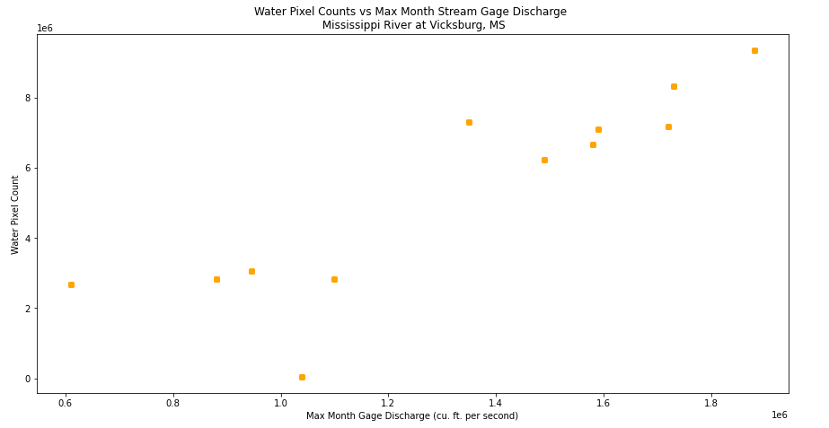

Plot above shows water pixel count (representing river water area) versus stream gage data (representing river water volume) for the Vicksburg, Mississippi monitoring site on the Mississippi River. Data spans the year of 2019.

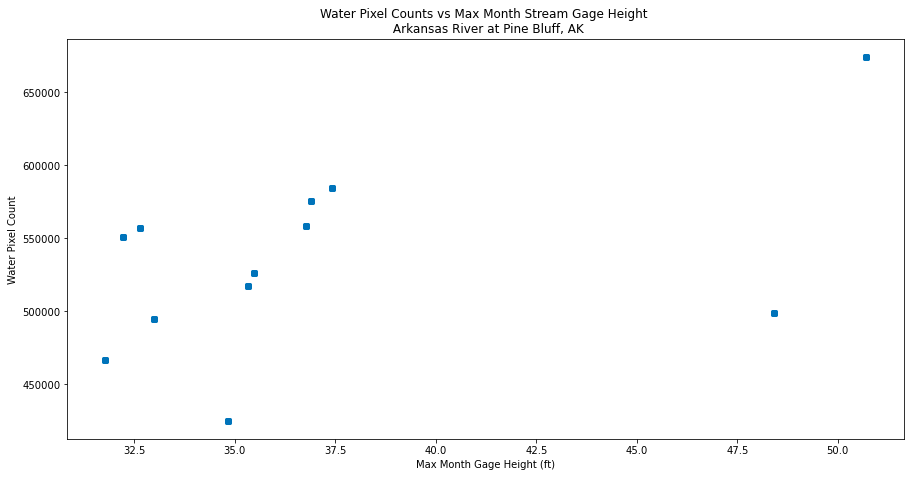

Plot above shows water pixel count (representing river water area) versus stream gage data (representing river water volume) for the Pine Bluff, Arkansas monitoring site on the Arkansas River. Data spans the year of 2019.

Throughout the process of generating the above plots, we also discovered a number of important factors that may affect the outcome. For example, we found that for sites that have nearby agricultural fields surrounding the river banks, it is important to uniquely identify site boundaries such that they capture primarly the river and banks. Additionally, cloud coverage can affect the availability of satellite data for certain site and at certain times, so it is important to span a long enough time period so as to ensure sufficient data quantity and quality.

## Why does it matter?

Major flood events impact a vast number of communities through the United States every year, and as climate change continues to destabilize river ecosystems and patterns, the increasing damages resulting from river flooding must be dealt with. The more information we have regarding flood events and their surface-area extent as a function of stream gage data, the better chances we have at eventually developing a tool to predict and plan for extreme flood events by using readily available sources of data.

Additionally, this kind of tool can help members in the infrastructure industry have more accurate and reliable data and insight on which to base design standards off of. This data analysis can be used to validate and verify (or invalidate) long-established infrastructure design standards that are primarily based on theory, rather than actual data. More accurate and reliable design standards lead to more flood-resilient infrastructure and planning, which in turn helps to mitigate the devastating damages that can occur from major flood events.

## Here's How We Did It

There was a two-part analysis required for this project: one part involved working with satellite data from Sentinel-2, and the other involved working with USGS stream gage data. First we obtained satellite imagery for each month of 2019 for our two sites, and collected water pixel count values for each of those images. To do this, we generated normalized difference water index (NDWI) images, which uses green and near-infrared bands from satellite images to display areas of high water content. See images below for wet and dry season NDWI images for both sites.

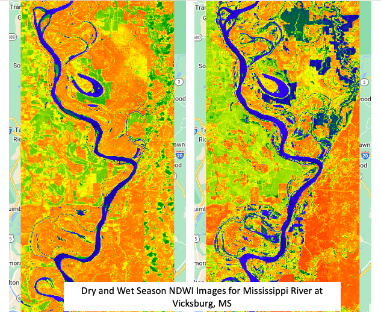

[figure not shown]

Next, we generated water pixel maps for both sites by isolating the blue water pixels in the NDWI images for each month of 2019. From these water pixel images, we were able to obtain water pixel count values, which can provide an indication of the amount of surface area covered by water before, during, and after major flood events.

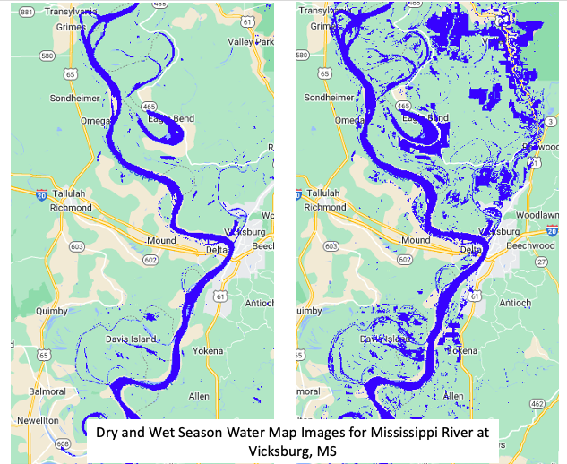

[figure not shown]

The second part of our analysis involved obtaining stream gage data for both sites, and plotting it against water pixel counts for both sites. We used stream gage discharge (in cubic feet per second) data for the Vicksburg, Mississippi site, and stream gage height (in feet) data for the Pine Bluff, Arkansas site. Once we extracted maximum monthly values in 2019 for each site, we plotted those values against the monthly water pixel count values to generate the plots at the beginning of this report.

## Implications and Potential Applications

There are a some very beneficial implications and potential applications for this project. This methodology and analysis can be reused for other sites and flood events to help validate the hypothesis that stream gage discharge measurements may be more closely correlated to flooding surface area extent than stream gage height data. A better understanding of the relationship between stream gage data and the reach of major flood events may help engineers, designers, and planners ensure that their design standards for nearby infrastructure appropriately address potential flood events.

Several other industries and community members are also heavily affected by flood events, such as agricultural communities, residential home-owners, business-owners, and taxpayers. The more information and insight we can provide with regards to potential flooding extents, particularly as a function of stream gage data (which is collected daily and readily available), the better protected all of these affected communities can be from major river flood events.

## Where to Find Out More

Please visit our GitHub repository to see all notebooks, reports, presentations, and documentation related to our project.

Link to GitHub repository: https://github.com/AvraSaslow/ea-rimorphis

## References

### Stream Gage Data

Pine Bluff, AR Site: U.S. Geological Survey, 2016, National Water Information System data available on the World Wide Web (USGS Water Data for the Nation), accessed April 27, 2022, at URL [https://waterdata.usgs.gov/nwis/dv?cb_00065=on&format=gif_default&site_no=07263650&referred_module=sw&period=&begin_date=2019-01-02&end_date=2020-01-01].

Vicksburg, MS Site: U.S. Geological Survey, 2016, National Water Information System data available on the World Wide Web (USGS Water Data for the Nation), accessed April 27, 2022, at URL [https://waterdata.usgs.gov/nwis/uv?site_no=07289000].

### Sentinel-2 Data

Sentinel-2 (ESA) images courtesy of the U.S. Geological Survey

'Copernicus Sentinel data 2019, 2021' for Sentinel data;